# Python LevelUP: Data Science by Appsilon

Machine Learning

Piotr Pasza Storożenko@Appsilon

# Problems machine learning solve

## How do we divide ML

- Supervised (pol. Nadzorowane)
  - Classification (pol. Klasyfikacja)
  - Regression (pol. Regresja)
- Unsupervised (pol. Nienadzorowane)
  - Clustering (pol. Analiza skupień)

## Classification

Our aim is to predict the **discrete** value.

Example classification problems:

- Model that distinguishes between cats and dogs
- Document classification into given classes
- Deciding whether tweet is toxic or not
- Product categorization
- Fraud detection

## Regression

Our aim is to predict the **continuous** value.

Example regression problems:

- Real estate price prediction
- Sales revenue prediction
- Age estimation

## Clustering

Our aim is to **find similar** entities.

Example clustering problems:

- Find similar products
- Suggest similar artists

# Basic rules of approaching ML problems

## Metric

To solve an ML problem we must be able to say which model is good and which bad.

The single number that will decide whether the model is good or bad is called **metric**.

With metric we can ask the computer to find *the best model*.

We use different metrics in different tasks.

## Example regression metrics:

- Mean square error
- Mean absolute error

## Example classification metrics

- Accuracy
- Precision
- Recall
- F1

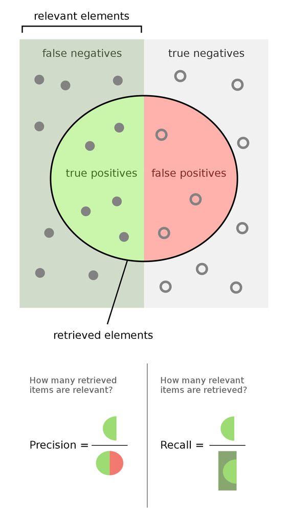

## What is learned from what

We start with the whole dataset and divide its columns into `X` and `y`.

- `X` is matrix with columns, features that will be used to train the model
- `y` is a **target** vector

Examples:

In case of flats price prediction, `X` will consist of columns like flat size, number of rooms, number of bathrooms, indication if flat has a balcony and so on. `y` will be the price.

In case of cats vs dogs prediction, the `X` are pixels values, `y` is label `cat`/`dog`.

## Train test split

We usually want to train the model on part of data and check it’s performance on the rest.

The basic approach to this is train test split:

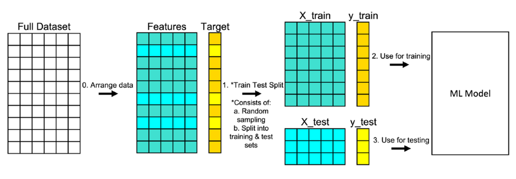

Source: https://towardsdatascience.com/understanding-train-test-split-scikit-learn-python-ea676d5e3d1

## Train test split

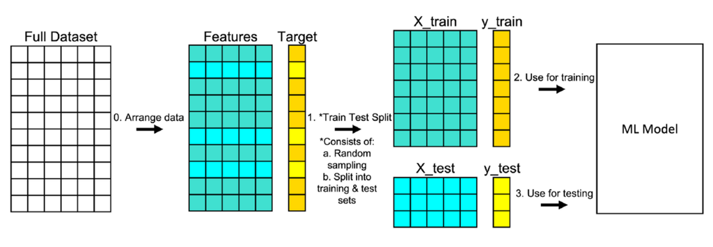

1. Train model `m` on `X_train` and `y_train`.
2. Get predictions `y_pred` by evaluating model `m` on `X_test`.
3. Calculate metric by comparing `y_pred` and `y_test`.

Source: https://towardsdatascience.com/understanding-train-test-split-scikit-learn-python-ea676d5e3d1

# The most common columns transformations

The majority of models expect an input to be in form of numeric values. Often it’s not the case…

## One-hot encoding

The easiest way to convert categorical values to numeric is so called one-hot encoding.

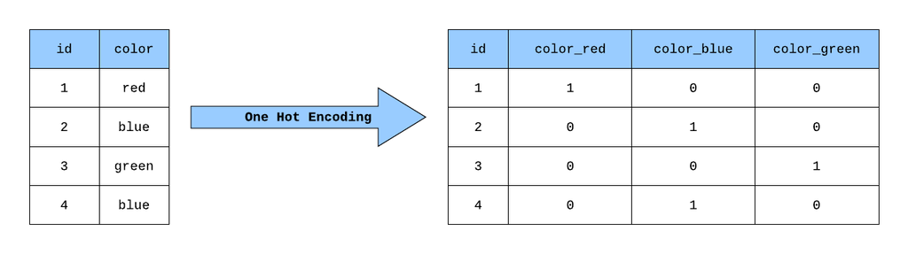

Source: https://towardsdatascience.com/building-a-one-hot-encoding-layer-with-tensorflow-f907d686bf39

## Smarter `NA` trick

We’ve learned how to fill `NA` with zeros in pandas.

Sometimes filling with median/mean value makes more sense. It’s worth experimenting and trying different approaches yourself!

A smart trick to get more information from `NA` is to, apart from filling it, add new column with boolean value like so:

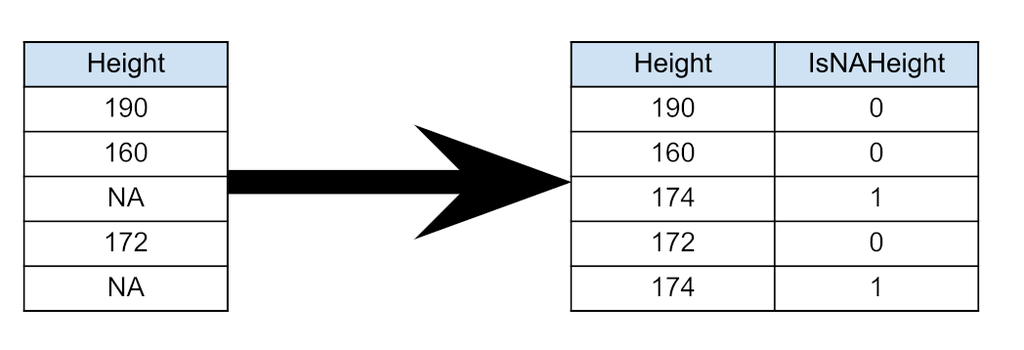

[figure not shown]